# Homework1

```r
## Started 16 January 2025 ##
## By Daniel Forrest ##

## Homework 1 for Bayes Class FRST 507C

### simulating various data configurations and estimating the data parameters using Bayesian linear models

# housekeeping
rm(list=ls())
options(stringsAsFactors=FALSE)

#read libraries
library(rstanarm)
library(here)
library(rstan)
####
here()
```

```
## [1] "/Users/pinskylab/Documents/GitHub/bayes2025homework/homeworksubmitted/daniel"
```

<> 1 – Simulate data for a linear regression problem (continuous predictor and response variables) of your choice and show a linear model can return the parameters you set. Your n should be 100 and you should set your error (sigma) to a level you would expect in an ecological or evolutionary biology study.

<> Lizzie, in this block, I simulate all data necessary for the full set of prompts

```r
# Set seed for reproducibility
set.seed(42)

# Simulation parameters
#create params
n = 100 # number of observations
a = 5 #intercept
b1 = 6 #effect size 1
b2 = -2 # effect size 2
b3 = 3 # effect size of interaction (half of b1 = 1.5)
# simulate predictor variables
x1 <- rnorm(n, 25, 12.5) # approximating temp in degrees C
x2 <- rbinom(n, 1, 0.5) # binary var: males and females, where males are more likely to positively covary with higher temps
sigma = 20

sigma2 = 10

# Simulate response variable (e.g., species abundance)
# Linear relationship: y = a+ beta_1 * x + error
yobs <- a + b1*x1 + rnorm(n, mean = 0, sd = sigma) ## simulating some species abundance (e.g., black-capped chickadees in Vancouver)
yobs2 <- a + b1*x1 + rnorm(n, mean = 0, sd = sigma2) ## simulating some species abundance (e.g., black-capped chickadees in Vancouver)

## center and scale predictors and response (i.e., z-score)
dat <- data.frame(x1, x2, yobs, yobs2)
dat.scaled <- as.data.frame(scale(dat))

# back to vectors
x1 <- dat$x1
x2 <- dat$x2
yobs <- dat$yobs
yobs2 <- dat$yobs2
```

Here is where I fit the linear model to estimate my original parameters, using rstan, generated using model1.stan

```r
# Prepare data for Stan
stan_data1 <- list(
  N = n,
  x = x1,
  y = yobs
)
# run stan model
fit1 <-stan(here("src","model1.stan"),
              data = c(stan_data1),
             chains = 4, iter = 2000, save_warmup=FALSE,
             #seed = 1, control=list(adapt_delta=0.9),
             init_r=1)
```

```
## Trying to compile a simple C file
```

[output not shown]

Here I compare model estimates to true parameters. The coefficient for predictor 1 (“beta1”) and sigma are fairly close, while the intercept is a bit far off.

```r
summary_fit <- summary(fit1, pars = c("a", "beta1", "sigma"))$summary

a_mean <- summary_fit["a", "mean"]
beta1_mean <- summary_fit["beta1", "mean"]
sigma_mean <- summary_fit["sigma", "mean"]

# Compare true parameters with estimated parameters
cat("True intercept (a):", a, "\n")
```

```
## True intercept (a): 5
```

```r
cat("Estimated intercept:", a_mean, "\n")
```

```
## Estimated intercept: 2.04139
```

```r
cat("True slope (b1):", b1, "\n")
```

```
## True slope (b1): 6
```

```r
cat("Estimated slope:", beta1_mean, "\n")
```

```
## Estimated slope: 6.110515
```

```r
cat("True error standard deviation (sigma):", sigma, "\n")
```

```
## True error standard deviation (sigma): 20
```

```r
cat("Residual standard error:", sigma_mean, "\n")
```

```
## Residual standard error: 18.96445
```

Now I add the binary covariate, “x2” and simulate using the stan script, “model2.stan”

```r
# Prepare data for Stan
stan_data2 <- list(
  N = n,
  x1 = x1,
  x2 = x2,
  y = yobs
)
# run stan model
fit2 <-stan(here("src","model2.stan"),
              data = c(stan_data2),
             chains = 4, iter = 2000, save_warmup=FALSE,
             #seed = 1, control=list(adapt_delta=0.9),
             init_r=1)
```

```
## Trying to compile a simple C file
```

[output not shown]

And again, I check the estimated parameters vs. the true parameters. Here, the intercept estimate has improved, first predictor coefficient (~temperature, “x1”) is very close, but the second (“x2”) and third (“x1:x2”) predictors are still well off. Sigma was fairly well estimated.

```r
summary_fit <- summary(fit2, pars = c("a", "b1", "b2","b3", "sigma"))$summary

a_mean <- summary_fit["a", "mean"]
b1_mean <- summary_fit["b1", "mean"]
b2_mean <- summary_fit["b2", "mean"]
b3_mean <- summary_fit["b3", "mean"]
sigma_mean <- summary_fit["sigma", "mean"]

# Compare true parameters with estimated parameters
cat("True intercept (a):", a, "\n")
```

```
## True intercept (a): 5
```

```r
cat("Estimated intercept:", a_mean, "\n")
```

```
## Estimated intercept: 6.610341
```

```r
cat("True slope (b1):", b1, "\n")
```

```
## True slope (b1): 6
```

```r
cat("Estimated slope:", b1_mean, "\n")
```

```
## Estimated slope: 6.002862
```

```r
cat("True slope (b1):", b2, "\n")
```

```
## True slope (b1): -2
```

```r
cat("Estimated slope:", b2_mean, "\n")
```

```
## Estimated slope: -10.0736
```

```r
cat("True slope (b1):", b3, "\n")
```

```
## True slope (b1): 3
```

```r
cat("Estimated slope:", b3_mean, "\n")
```

```
## Estimated slope: 0.2100443
```

```r
cat("True error standard deviation (sigma):", sigma, "\n")
```

```
## True error standard deviation (sigma): 20
```

```r
cat("Residual standard error:", sigma_mean, "\n")
```

```
## Residual standard error: 18.96154
```

Here I sample just 20% of my data and re-format for stan.

```r
# Take a random 20% sample
set.seed(42)  # For reproducibility

# Select 20 random row indices
row_indices <- sample(1:100, 20)

# Subset each element based on its type
stan_data3 <- lapply(stan_data2[2:4], function(x) {
  if (is.data.frame(x) || is.matrix(x)) {
    x[row_indices, , drop = FALSE]  # Subset for data frames or matrices
  } else if (is.vector(x)) {
    x[row_indices]  # Subset for vectors
  } else {
    stop("Unsupported data type in list")  # Error handling for unsupported types
  }
})

n = 20

stan_data3 <- c(list(N=n), stan_data3)
```

And here I fit the same model as above, but with only 20% of the data

```r
# run stan model
fit3 <-stan(here("src","model2.stan"),
              data = c(stan_data3),
             chains = 4, iter = 2000, save_warmup=FALSE,
             #seed = 1, control=list(adapt_delta=0.9),
             init_r=1)
```

Now, more of the estimated parameters are far off. The model has only 1/5 of the information to work with, and therefore, a different model solution could generate similar patterns as the data, due to the low sample size and variation (i.e., noise, i.e., error).

```r
summary_fit <- summary(fit3, pars = c("a", "b1", "b2","b3", "sigma"))$summary

a_mean <- summary_fit["a", "mean"]
b1_mean <- summary_fit["b1", "mean"]
b2_mean <- summary_fit["b2", "mean"]
b3_mean <- summary_fit["b3", "mean"]
sigma_mean <- summary_fit["sigma", "mean"]

# Compare true parameters with estimated parameters
cat("True intercept (a):", a, "\n")
```

```
## True intercept (a): 5
```

```r
cat("Estimated intercept:", a_mean, "\n")
```

```
## Estimated intercept: 10.11908
```

```r
cat("True slope (b1):", b1, "\n")
```

```
## True slope (b1): 6
```

```r
cat("Estimated slope:", b1_mean, "\n")
```

```
## Estimated slope: 5.944475
```

```r
cat("True slope (b1):", b2, "\n")
```

```
## True slope (b1): -2
```

```r
cat("Estimated slope:", b2_mean, "\n")
```

```
## Estimated slope: -27.74059
```

```r
cat("True slope (b1):", b3, "\n")
```

```
## True slope (b1): 3
```

```r
cat("Estimated slope:", b3_mean, "\n")
```

```
## Estimated slope: 1.333023
```

```r
cat("True error standard deviation (sigma):", sigma, "\n")
```

```
## True error standard deviation (sigma): 20
```

```r
cat("Residual standard error:", sigma_mean, "\n")
```

```
## Residual standard error: 18.85662
```

Prompt: “Next, let’s make a plot of sampling from your data from 1 to the n of your data (100) showing the estimated parameters for each sample size. Make a plot with your 1:100 on the horizontal axis and your estimated parameters on the vertical (you need either as many plots as parameters or a way to show all the different parameters on one plot). Compare how well the model does across the different parameters. Which is better or worse at and why?”

```r
n = 100

fit_objects <- list()

# Function to fit model for varying sample sizes
fit_varying_samples_stan <- function(n_subsample, n_reps = 1) {
  estimates <- matrix(NA, nrow = n_reps, ncol = 5)  # For beta0, beta1, beta2, beta3
  colnames(estimates) <- c("a", "b1", "b2", "b3", "sigma")

  for (rep in 1:n_reps) {
    sample_indices <- sample(1:n, size = n_subsample)
    stan_data_sample <- list(
      N = length(sample_indices),
      x1 = x1[sample_indices],
      x2 = x2[sample_indices],
      y = yobs[sample_indices]
    )

    # run stan model
    fit <-stan(here("src","model2.stan"),
              data = c(stan_data_sample),
             chains = 4, iter = 2000, save_warmup=FALSE,
             #seed = 1, control=list(adapt_delta=0.9),
             init_r=1)
    fit_objects[[rep]] <- fit
    estimates[rep, ] <- summary(fit)$summary[c("a", "b1", "b2", "b3", "sigma"), "mean"]
  }

  colMeans(estimates)  # Average estimates across reps
}


# Compute estimates for sample sizes 1 to 100
n_reps <- 1  # Single draw for now
sample_sizes <- c(20,30,40,50,60,70,80,90,100) #could not converge with 5, nor 10 samples
fit_results <- lapply(sample_sizes, fit_varying_samples_stan, n_reps = n_reps)
print(fit_results)
```

```
## [[1]]
##          a         b1         b2         b3      sigma
##  13.192486   5.339109 -25.017033   1.063455  20.901446
##
## [[2]]
##          a         b1         b2         b3      sigma
##  2.1461515  6.2261884 -4.4292249  0.1636942 20.7802170
##
## [[3]]
##           a          b1          b2          b3       sigma
##  14.3260188   5.7833670 -29.1983371   0.7803084  18.1220508
##
## [[4]]
##           a          b1          b2          b3       sigma
##  12.7285677   5.7834644 -15.4756828   0.5223149  21.6275224
##
## [[5]]
##          a         b1         b2         b3      sigma
##  3.3966936  6.1130807 -6.8754112  0.1985244 19.7588020
##
## [[6]]
##           a          b1          b2          b3       sigma
##   6.8745950   5.9172975 -10.6993397   0.3251544  19.2145672
##
## [[7]]
##           a          b1          b2          b3       sigma
##  10.0927713   5.9543920 -13.5158954   0.2022589  19.0076104
##
## [[8]]
##           a          b1          b2          b3       sigma
##   7.7564179   5.9746083 -10.2902621   0.1644091  19.0632049
##
## [[9]]
##           a          b1          b2          b3       sigma
##   6.7446207   5.9999216 -10.1380795   0.2103837  18.9768054
```

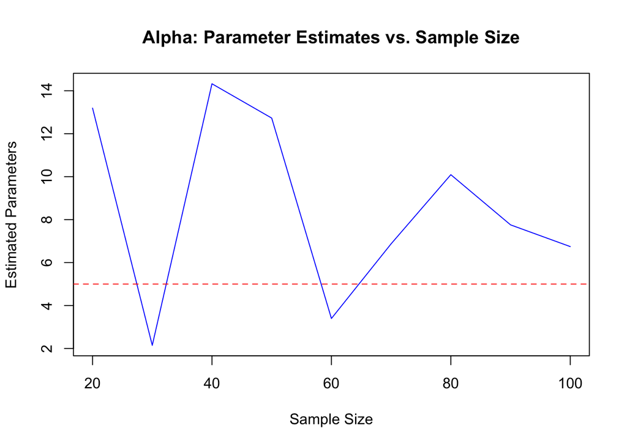

```
## integer(0)
```

```r
a_coef <- c()
b1_coef <- c()
b2_coef <- c()
b3_coef <- c()
sigma_coef <- c()
for (i in 1:9){
  a_coef[i] <- fit_results[[i]]["a"]
  b1_coef[i] <- fit_results[[i]]["b1"]
  b2_coef[i] <- fit_results[[i]]["b2"]
  b3_coef[i] <- fit_results[[i]]["b3"]
  sigma_coef[i] <- fit_results[[i]]["sigma"]
}

# Plot parameter estimates
plot(sample_sizes, a_coef, type = "l", col = "blue", ylim = range(a_coef, a),
     xlab = "Sample Size", ylab = "Estimated Parameters", main = "Alpha: Parameter Estimates vs. Sample Size")+ abline(h = a, col = "red", lty = 2)
```

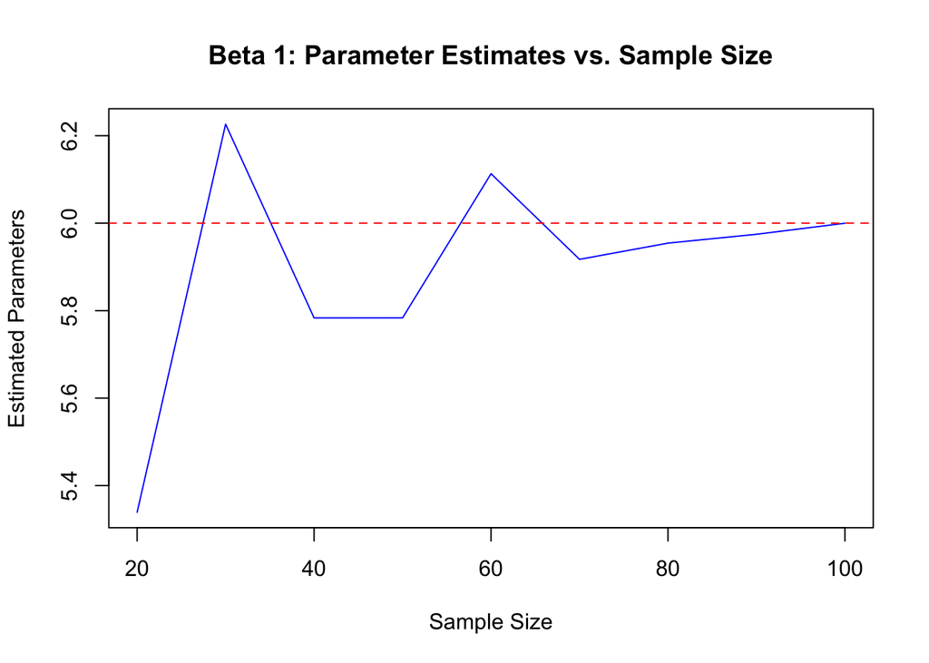

```
## integer(0)
```

```r
plot(sample_sizes, b1_coef, type = "l", col = "blue", ylim = range(b1_coef, b1),
     xlab = "Sample Size", ylab = "Estimated Parameters", main = "Beta 1: Parameter Estimates vs. Sample Size")+ abline(h = b1, col = "red", lty = 2)
```

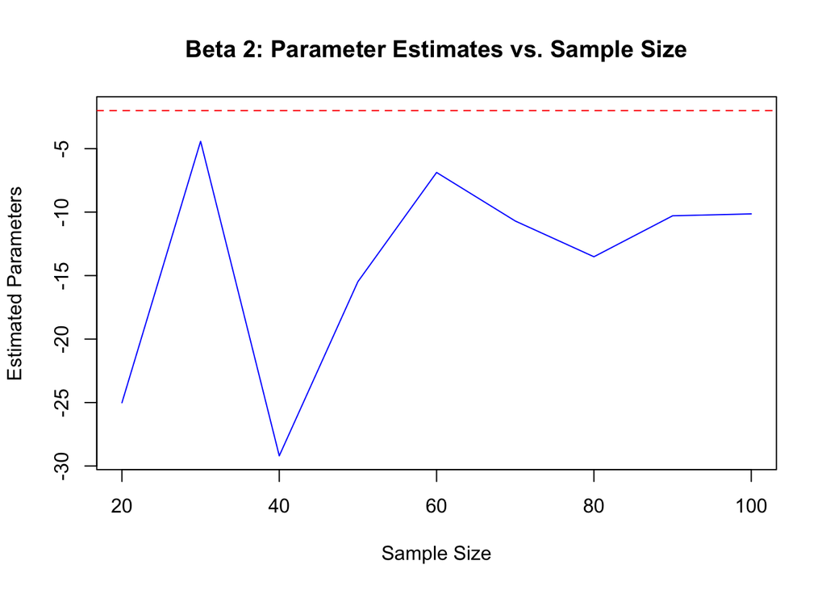

```
## integer(0)
```

```r
plot(sample_sizes, b2_coef, type = "l", col = "blue", ylim = range(b2_coef, b2),
     xlab = "Sample Size", ylab = "Estimated Parameters", main = "Beta 2: Parameter Estimates vs. Sample Size")+ abline(h = b2, col = "red", lty = 2)
```

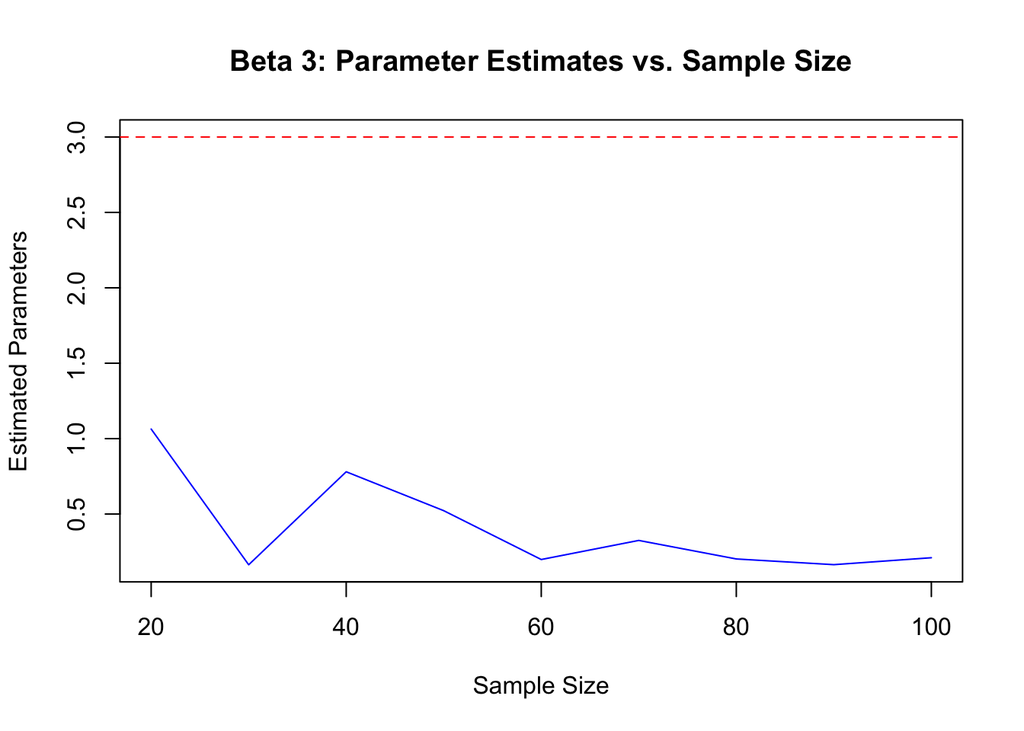

```
## integer(0)
```

```r
plot(sample_sizes, b3_coef, type = "l", col = "blue", ylim = range(b3_coef, b3),
     xlab = "Sample Size", ylab = "Estimated Parameters", main = "Beta 3: Parameter Estimates vs. Sample Size")+ abline(h = b3, col = "red", lty = 2)
```

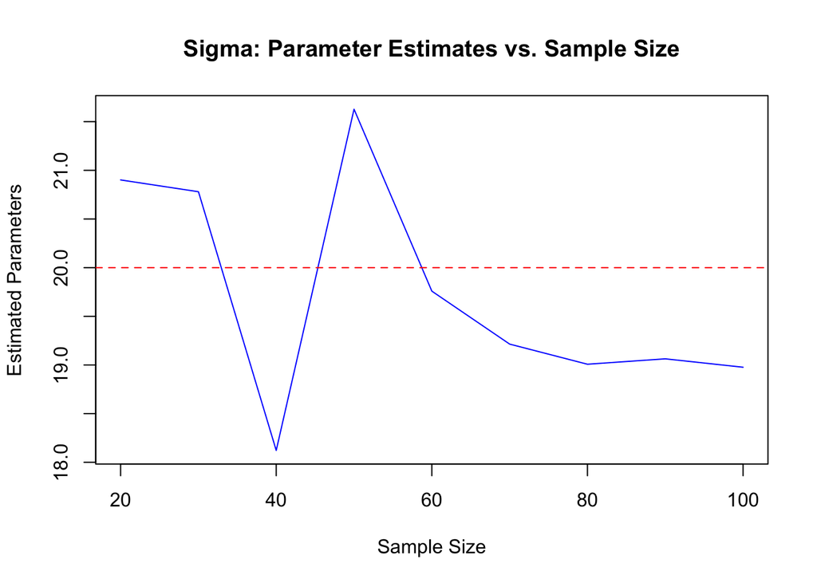

```
## integer(0)
```

```r
plot(sample_sizes, sigma_coef, type = "l", col = "blue", ylim = range(sigma_coef, sigma),
     xlab = "Sample Size", ylab = "Estimated Parameters", main = "Sigma: Parameter Estimates vs. Sample Size")+ abline(h = sigma, col = "red", lty = 2)
```

Prompt: Let’s improve our sampling now. So far we have take just ONE draw from our set of parameters which means our sigma term has some Monte Carlo error in it, so let’s take 10 draws each time (so we need to set up a loop or such in R that samples from 1:n and at each step it repeats simulating the data and getting the estimates 10 times). Re-make your plot. (If you get stuck here for a while, don’t panic, but move onto Steps 3-4.)

```r
fit_objects <- list()

# Function to fit model for varying sample sizes
fit_varying_samples_stan <- function(n_subsample, n_reps = 10) {
  estimates <- matrix(NA, nrow = n_reps, ncol = 5)  # For beta0, beta1, beta2, beta3
  colnames(estimates) <- c("a", "b1", "b2", "b3", "sigma")

  for (rep in 1:n_reps) {
    sample_indices <- sample(1:n, size = n_subsample)
    stan_data_sample <- list(
      N = length(sample_indices),
      x1 = x1[sample_indices],
      x2 = x2[sample_indices],
      y = yobs[sample_indices]
    )

    # run stan model
    fit <-stan(here("src","model2.stan"),
              data = c(stan_data_sample),
             chains = 4, iter = 2000, save_warmup=FALSE,
             #seed = 1, control=list(adapt_delta=0.9),
             init_r=1)
    fit_objects[[rep]] <- fit
    estimates[rep, ] <- summary(fit)$summary[c("a", "b1", "b2", "b3", "sigma"), "mean"]
  }

  colMeans(estimates)  # Average estimates across reps
}


# Compute estimates for sample sizes 1 to 100
sample_sizes <- c(20,30,40,50,60,70,80,90,100) #could not converge with 5, nor 10 samples
fit_results <- lapply(sample_sizes, fit_varying_samples_stan, n_reps = n_reps)
print(fit_results)
```

```
## [[1]]
##           a          b1          b2          b3       sigma
##  10.2419729   5.9016931 -15.6152290   0.6809298  26.3470262
##
## [[2]]
##           a          b1          b2          b3       sigma
##   5.7605862   5.8763790 -21.3645867   0.4747769  19.0898830
##
## [[3]]
##           a          b1          b2          b3       sigma
##  -0.7369287   6.0333281 -11.2577156   0.2780191  18.5132193
##
## [[4]]
##           a          b1          b2          b3       sigma
##  19.4151503   5.4934500 -19.3142851   0.5184992  17.3792058
##
## [[5]]
##          a         b1         b2         b3      sigma
##   7.211684   6.023953 -15.598898   0.266163  19.766811
##
## [[6]]
##           a          b1          b2          b3       sigma
##   9.3952323   6.0305637 -16.5622793   0.3523553  19.4301321
##
## [[7]]
##          a         b1         b2         b3      sigma
##  7.8564409  5.9500079 -9.1329344  0.2174819 18.9930195
##
## [[8]]
##          a         b1         b2         b3      sigma
##  6.1172273  6.0147761 -6.1042788  0.1188058 18.6050526
##
## [[9]]
##           a          b1          b2          b3       sigma
##   6.7386498   6.0016380 -10.0791251   0.2100436  18.9246052
```

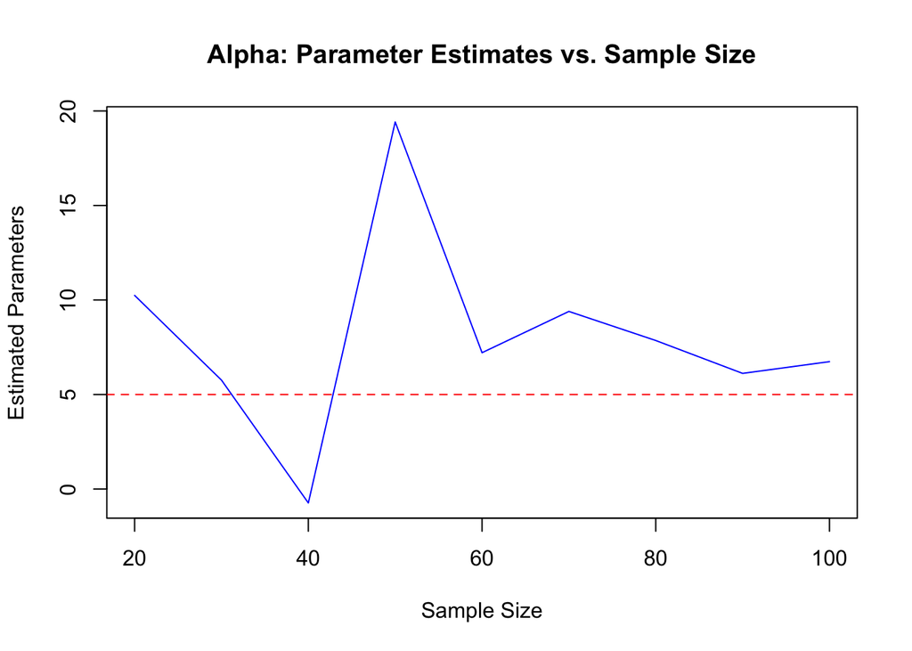

```
## integer(0)
```

```r
a_coef <- c()
b1_coef <- c()
b2_coef <- c()
b3_coef <- c()
sigma_coef <- c()
for (i in 1:9){
  a_coef[i] <- fit_results[[i]]["a"]
  b1_coef[i] <- fit_results[[i]]["b1"]
  b2_coef[i] <- fit_results[[i]]["b2"]
  b3_coef[i] <- fit_results[[i]]["b3"]
  sigma_coef[i] <- fit_results[[i]]["sigma"]
}

# Plot parameter estimates
plot(sample_sizes, a_coef, type = "l", col = "blue", ylim = range(a_coef, a),
     xlab = "Sample Size", ylab = "Estimated Parameters", main = "Alpha: Parameter Estimates vs. Sample Size")+ abline(h = a, col = "red", lty = 2)
```

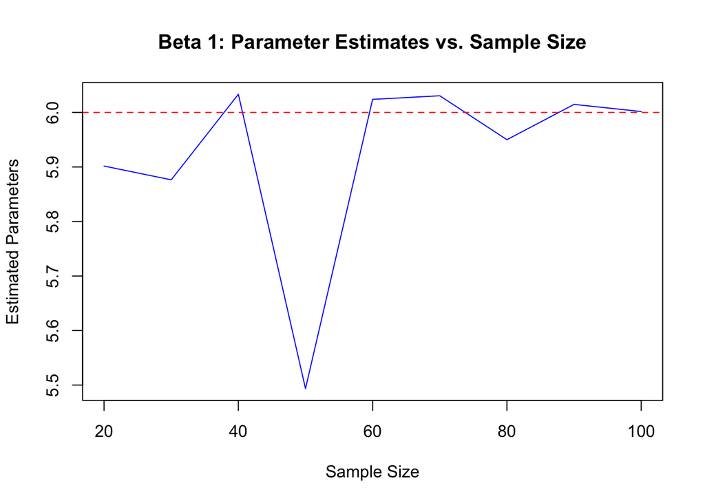

```
## integer(0)
```

```r
plot(sample_sizes, b1_coef, type = "l", col = "blue", ylim = range(b1_coef, b1),
     xlab = "Sample Size", ylab = "Estimated Parameters", main = "Beta 1: Parameter Estimates vs. Sample Size")+ abline(h = b1, col = "red", lty = 2)
```

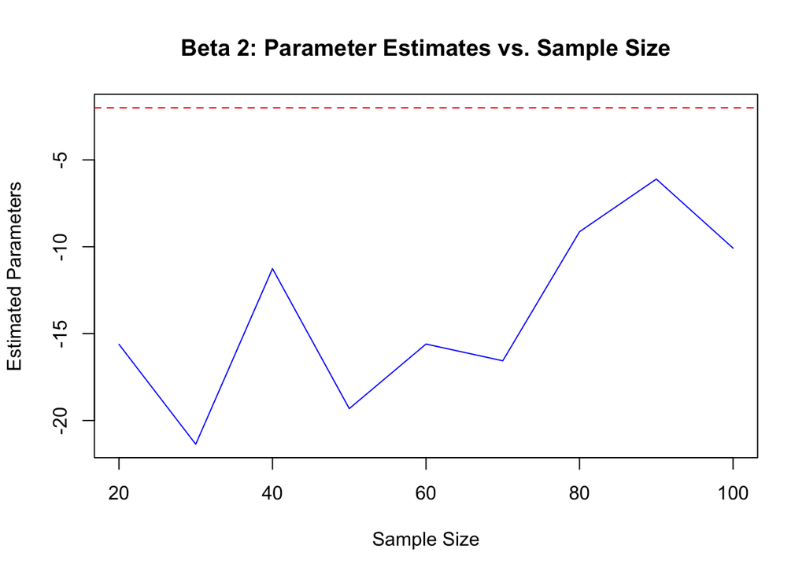

```
## integer(0)
```

```r
plot(sample_sizes, b2_coef, type = "l", col = "blue", ylim = range(b2_coef, b2),
     xlab = "Sample Size", ylab = "Estimated Parameters", main = "Beta 2: Parameter Estimates vs. Sample Size")+ abline(h = b2, col = "red", lty = 2)
```

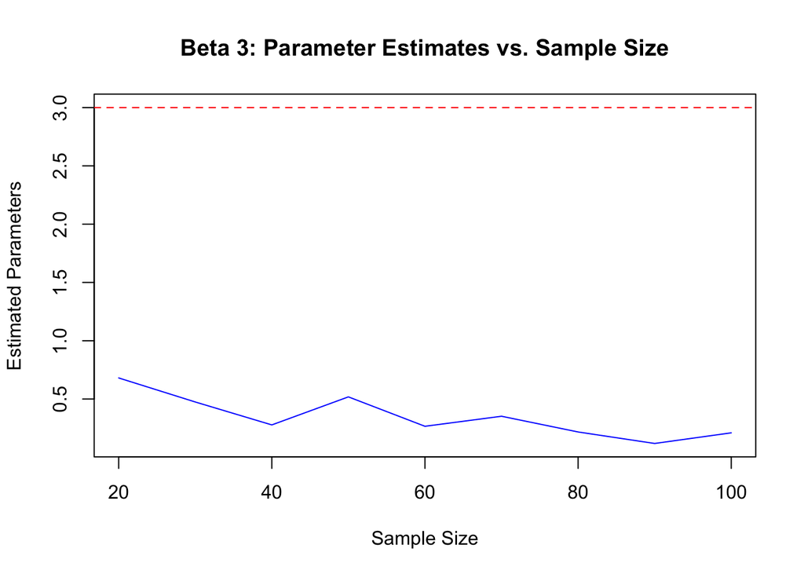

```
## integer(0)
```

```r
plot(sample_sizes, b3_coef, type = "l", col = "blue", ylim = range(b3_coef, b3),
     xlab = "Sample Size", ylab = "Estimated Parameters", main = "Beta 3: Parameter Estimates vs. Sample Size")+ abline(h = b3, col = "red", lty = 2)
```

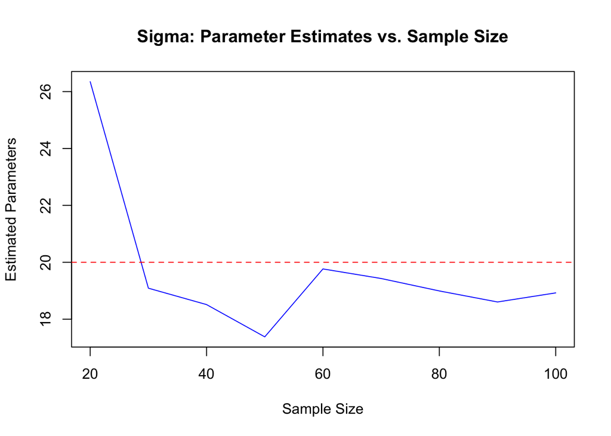

```
## integer(0)
```

```r
plot(sample_sizes, sigma_coef, type = "l", col = "blue", ylim = range(sigma_coef, sigma),
     xlab = "Sample Size", ylab = "Estimated Parameters", main = "Sigma: Parameter Estimates vs. Sample Size")+ abline(h = sigma, col = "red", lty = 2)
```

```r
fit_objects <- list()

# Function to fit model for varying sample sizes
fit_varying_samples_stan <- function(n_subsample, n_reps = 10) {
  estimates <- matrix(NA, nrow = n_reps, ncol = 5)  # For beta0, beta1, beta2, beta3
  colnames(estimates) <- c("a", "b1", "b2", "b3", "sigma")

  for (rep in 1:n_reps) {
    sample_indices <- sample(1:n, size = n_subsample)
    stan_data_sample <- list(
      N = length(sample_indices),
      x1 = x1[sample_indices],
      x2 = x2[sample_indices],
      y = yobs2[sample_indices]
    )

    # run stan model
    fit <-stan(here("src","model2.stan"),
              data = c(stan_data_sample),
             chains = 4, iter = 2000, save_warmup=FALSE,
             #seed = 1, control=list(adapt_delta=0.9),
             init_r=1)
    fit_objects[[rep]] <- fit
    estimates[rep, ] <- summary(fit)$summary[c("a", "b1", "b2", "b3", "sigma"), "mean"]
  }

  colMeans(estimates)  # Average estimates across reps
}


# Compute estimates for sample sizes 1 to 100
sample_sizes <- c(20,30,40,50,60,70,80,90,100) #could not converge with 5, nor 10 samples
fit_results <- lapply(sample_sizes, fit_varying_samples_stan, n_reps = n_reps)
print(fit_results)
```

```
## [[1]]
##          a         b1         b2         b3      sigma
## 16.0009474  5.6383642 -7.0176893  0.4642195 11.8477971
##
## [[2]]
##          a         b1         b2         b3      sigma
## 15.4177469  5.7012459 -5.8657148  0.1243799  9.2470607
##
## [[3]]
##           a          b1          b2          b3       sigma
##   8.3316126   5.8561456 -11.8665819   0.7120463   9.8365948
##
## [[4]]
##          a         b1         b2         b3      sigma
##  5.9923382  5.9154454 -9.9320010  0.3129383  8.9559285
##
## [[5]]
##         a        b1        b2        b3     sigma
##  9.769538  5.816082 -6.957562  0.265623  9.848482
##
## [[6]]
##          a         b1         b2         b3      sigma
##  9.1231041  5.7793106 -9.3675325  0.4374872  8.7321844
##
## [[7]]
##          a         b1         b2         b3      sigma
##  6.7054323  5.9514329 -7.8049326  0.2375229  8.9716238
##
## [[8]]
##          a         b1         b2         b3      sigma
##  8.5958890  5.8471376 -9.4157931  0.3530671  9.0610789
##
## [[9]]
##          a         b1         b2         b3      sigma
##  7.2127829  5.8991259 -7.8345682  0.3049988  9.3197557
```

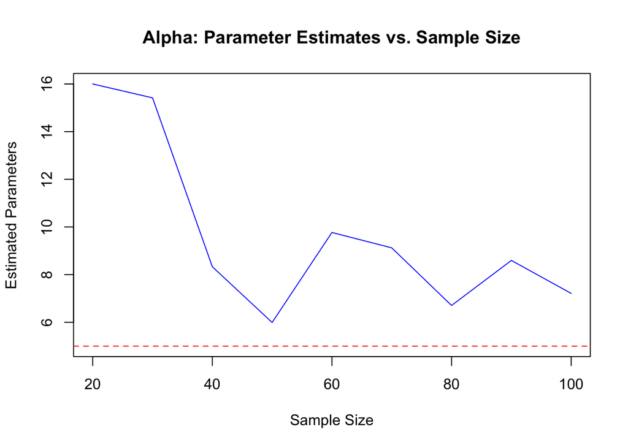

```
## integer(0)
```

```r
a_coef <- c()
b1_coef <- c()
b2_coef <- c()
b3_coef <- c()
sigma_coef <- c()
for (i in 1:9){
  a_coef[i] <- fit_results[[i]]["a"]
  b1_coef[i] <- fit_results[[i]]["b1"]
  b2_coef[i] <- fit_results[[i]]["b2"]
  b3_coef[i] <- fit_results[[i]]["b3"]
  sigma_coef[i] <- fit_results[[i]]["sigma"]
}

# Plot parameter estimates
plot(sample_sizes, a_coef, type = "l", col = "blue", ylim = range(a_coef, a),
     xlab = "Sample Size", ylab = "Estimated Parameters", main = "Alpha: Parameter Estimates vs. Sample Size")+ abline(h = a, col = "red", lty = 2)
```

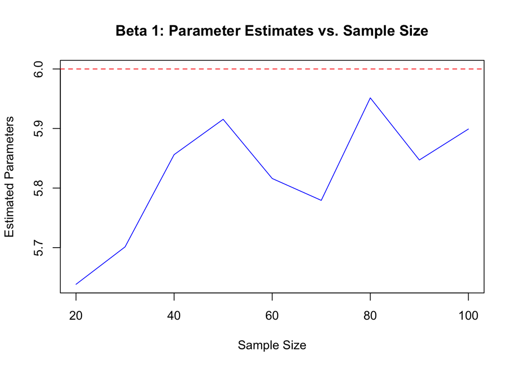

```
## integer(0)
```

```r
plot(sample_sizes, b1_coef, type = "l", col = "blue", ylim = range(b1_coef, b1),
     xlab = "Sample Size", ylab = "Estimated Parameters", main = "Beta 1: Parameter Estimates vs. Sample Size")+ abline(h = b1, col = "red", lty = 2)
```

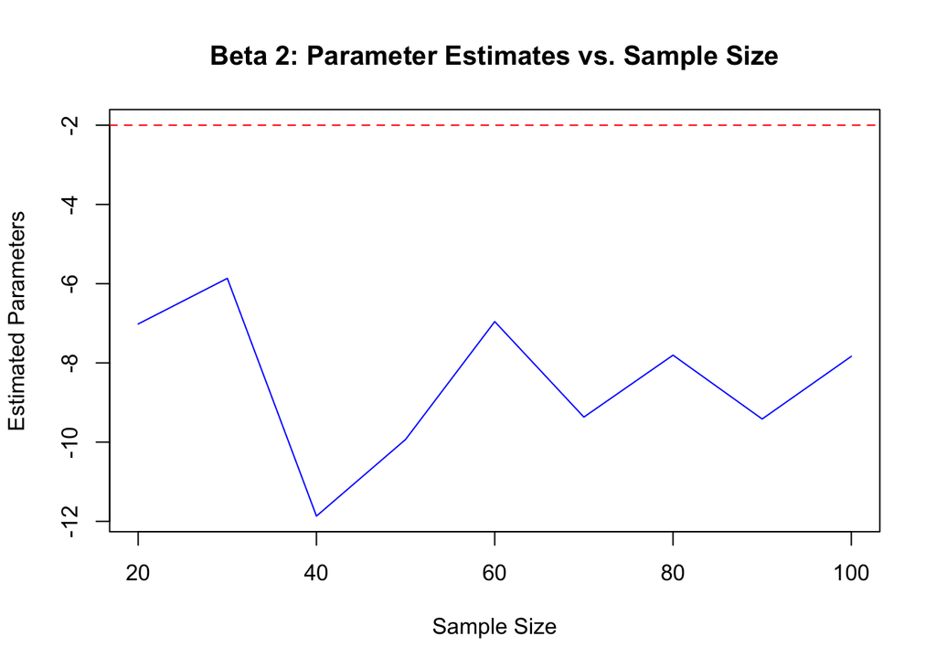

```
## integer(0)
```

```r
plot(sample_sizes, b2_coef, type = "l", col = "blue", ylim = range(b2_coef, b2),
     xlab = "Sample Size", ylab = "Estimated Parameters", main = "Beta 2: Parameter Estimates vs. Sample Size")+ abline(h = b2, col = "red", lty = 2)
```

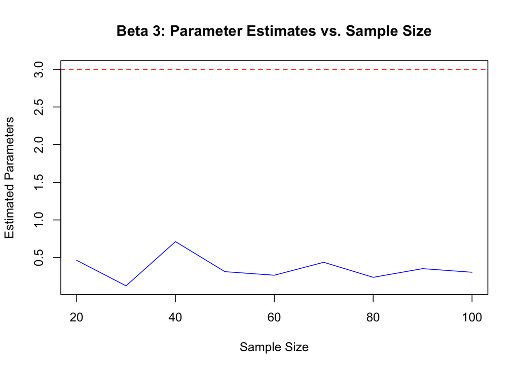

```
## integer(0)
```

```r
plot(sample_sizes, b3_coef, type = "l", col = "blue", ylim = range(b3_coef, b3),
     xlab = "Sample Size", ylab = "Estimated Parameters", main = "Beta 3: Parameter Estimates vs. Sample Size")+ abline(h = b3, col = "red", lty = 2)
```

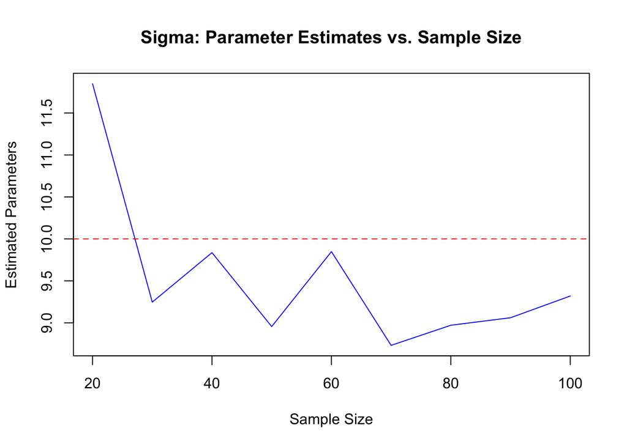

```
## integer(0)
```

```r
plot(sample_sizes, sigma_coef, type = "l", col = "blue", ylim = range(sigma_coef, sigma2),
     xlab = "Sample Size", ylab = "Estimated Parameters", main = "Sigma: Parameter Estimates vs. Sample Size")+ abline(h = sigma2, col = "red", lty = 2)
```

Beginning to work on Challenge C

```r
#
#
#
# fit_varying_samples_stan <- function(n_subsample, n_reps = 10) {
#   fit_objects <- list()  # Create a local list
#   estimates <- matrix(NA, nrow = n_reps, ncol = 5)  # For beta0, beta1, beta2, beta3
#   colnames(estimates) <- c("a", "b1", "b2", "b3", "sigma")
#
#   for (rep in 1:n_reps) {
#     sample_indices <- sample(1:n, size = n_subsample)
#     stan_data_sample <- list(
#       N = length(sample_indices),
#       x1 = x1[sample_indices],
#       x2 = x2[sample_indices],
#       y = yobs2[sample_indices]
#     )
#
#     # Run Stan model
#     fit <- stan(here("src", "model2.stan"),
#                 data = c(stan_data_sample),
#                 chains = 4, iter = 2000, save_warmup = FALSE,
#                 init_r = 1)
#     fit_objects[[rep]] <- fit
#     estimates[rep, ] <- summary(fit)$summary[c("a", "b1", "b2", "b3", "sigma"), "mean"]
#   }
#
#   return(fit_objects)  # Return the list of Stan model objects
# }
#
# sample_sizes <- c(20,30,40,50,60,70,80,90,100) #could not converge with 5, nor 10 samples
# fit_results <- lapply(sample_sizes, fit_varying_samples_stan, n_reps = n_reps)
# print(fit_results)
#
#
#
# # Set a seed for replicability
# set.seed(1234)
#
# #### CHANGE THESE FOR EACH MODEL
# # Extract posterior samples
#
#
# # Create an empty list to store posterior samples
# posterior_samples <- vector("list", length(fit_results))
#
# # Loop through each stanfit object in the list
# for (i in seq_along(fit_results)) {
#   # Extract the stanfit object from the nested list
#   stanfit_object <- fit_results[[i]][[1]]  # Assuming the stanfit object is the first element
#   posterior_samples[[i]] <- rstan::extract(stanfit_object)
# }
#
# for (i in seq_along(posterior_samples)){
#  posterior_samples[[i]]$a
# }
#
# # Extract necessary parameters
# N_rep <- posterior_samples$N
# p_rep <- posterior_samples$p
#
# # Define the number of draws for visualization
# num_draws <- 50
# draw_indices <- sample(seq_len(nrow(N_rep)), num_draws)
#
#
# pp_data <- vector("list", num_draws)
#
# # Generate new samples
# for (i in seq_along(draw_indices)) {
#   draw_index <- draw_indices[i]
#   N_draw <- N_rep[draw_index, ]  # 1x11
#   p_draw <- p_rep[draw_index]    # single value
#
#   # Generate a new 4x11 sample using the binomial distribution
#   pp_data[[i]] <- matrix(rbinom(4 * 11, size = N_draw, prob = p_draw), nrow = 4, ncol = 11)
# }
#
# # Flatten the observed data if it's not already a vector
# if (!is.vector(y)) {
#   y <- c(y)
# }
#
# # Combine the posterior predictive data into a single data frame
# num_draws <- length(pp_data)
#
# # Convert each draw to a data frame with a draw identifier
# posterior_data <- do.call(rbind, lapply(seq_along(pp_data), function(i) {
#   data.frame(value = c(pp_data[[i]]), draw = paste("Posterior Draw", i), type = "Posterior samples")
# }))
#
# # Create a data frame for the observed data
# observed_data <- data.frame(value = y, draw = 'Observed', type = 'Observed')
#
# # Combine the data for ggplot
# combined_data <- bind_rows(observed_data, posterior_data)
#
# smoothing <- 1
# # Define colors with alpha transparency
# alpha_red <- scales::alpha("red", 0.4)
#
# # Plot using ggplot2
# ppcplot <- ggplot(combined_data, aes(x = value, color = type)) +
#   # Plot posterior predictive data
#   geom_density(data = subset(combined_data, type == "Posterior samples"), bw = smoothing,
#                aes(group = draw, color = type),
#                size = 0.7) +
#   # Plot observed data
#   geom_density(data = subset(combined_data, type == "Observed"), bw = smoothing,
#                aes(color = type),
#                size = 1.5) +
#   # Set manual colors and labels
#   scale_color_manual(values = c("Observed" = "blue", "Posterior samples" = alpha_red),
#                      labels = c("Observed" = "Observed", "Posterior samples" = "Posterior samples")) +
#   # Set plot labels and title
#   labs(title = "Posterior Predictive Check",
#        x = "Value",
#        y = "Density",
#        color = "Type") +
#   # Set theme
#   theme_minimal() +
#   theme(legend.position = "top") +
#   # Set legend guide overrides
#   guides(color = guide_legend(override.aes = list(size = 2)))
#
# print(ppcplot)
```